# Pollination Suitability Mapping for Crops

Germany, Belgium and the Netherlands | 2011-2022

Author

Hector Valdes Hurtado

Published

January 1, 2026

## 1. Introduction and Personas

### 1.1 Context

Pollinator-dependent crops account for a substantial share of agricultural output across Germany, Belgium, and the Netherlands. Climatic conditions during crop flowering directly govern bee foraging activity and, by extension, fruit and seed set. Farmers and advisors rarely have access to spatially explicit, crop-specific assessments of how often and where weather conditions are suitable for pollination. This project develops a regional **Pollination Suitability Index (PSI)** computed from daily observed climate data and cross-referenced with crop distribution, providing decision-relevant maps and statistics for three crops: rapeseed (*Brassica napus*), temperate fruit (TEMF), and sunflower (*Helianthus annuus*).

### 1.2 Persona 1: Lars Hoffmann (Regional Crop Insurance Analyst)

**Age:** 45 | **Location:** Munster, Germany

**Role:** Senior analyst at a regional agricultural insurer covering DE, BE and NL

Lars evaluates climatic risk exposure for pollination-dependent crops across multiple regions each season. He currently relies on point weather station data and annual yield statistics, which are slow to arrive and difficult to spatialise. He needs to identify *which NUTS-2 regions consistently experience unsuitable weather during critical bloom windows*, so he can price risk accurately, flag high-exposure zones for proactive client contact, and justify regional premium differentiation to underwriters.

**User Story 1: Risk Exposure Mapping**

As Lars, I want a ranked map of crop-weighted climate deficit exposure per region and crop, so that I can identify where systematic pollination risk is highest and adjust coverage strategies accordingly.

**User Story 2: Interannual Instability**

As Lars, I want to understand year-to-year variation in seasonal suitability, so that I can distinguish regions with consistently poor conditions from those that are merely unlucky in individual years.

### 1.3 Persona 2: Dr. Anneke Visser (Regional Agronomy Advisor)

**Age:** 36 | **Location:** Wageningen, Netherlands

**Role:** Pollination and crop health advisor at a cross-border agricultural cooperative covering NL, BE and western DE

Anneke supports farmers growing rapeseed, fruit, and sunflower across the study region. She understands crop phenology well but lacks a unified tool connecting bloom timing, spatial crop distribution, and historical climate suitability. She wants to identify *regions with a structural match between good climate and high crop presence*, and conversely, where high crop intensity coincides with persistently unsuitable weather.

**User Story 3: Suitability-Crop Overlap**

As Anneke, I want a map showing where crop-weighted suitability is highest per bloom window, so that I can benchmark regions and identify best-practice areas for farmer visits and demonstration plots.

**User Story 4: Spatial Hotspot Detection**

As Anneke, I want to know whether poor pollination climate is spatially clustered rather than random, so that I can plan regional advisory campaigns instead of treating each farm in isolation.

## 2. Research Questions

Three research questions structure the analysis, each linked directly to persona needs:

**Q1.** Where is spring climate suitability for pollination highest and most stable across DE-BE-NL during crop-specific bloom windows? *(addresses Lars US2 and Anneke US3)*

**Q2.** Where does each crop’s geographic distribution overlap with the most unsuitable climate conditions, and which regions carry the greatest crop-weighted deficit exposure? *(addresses Lars US1 and Anneke US3)*

**Q3.** Are crop-weighted suitability and deficit exposure patterns spatially clustered at the NUTS-2 level, and where are the significant hotspots? *(addresses Anneke US4)*

## 3. Data

### 3.1 E-OBS Daily Climate Grids (v27.0e)

Climate input is sourced from E-OBS (Cornes et al., 2018), a daily gridded observational dataset produced by the Copernicus Climate Change Service and the EURO4M project. The dataset covers Europe at **0.1 degree regular latitude-longitude resolution** (approximately 7-9 km at study latitudes). Two variables are used: ensemble mean daily mean temperature (`TG`, degC) and ensemble mean daily precipitation sum (`RR`, mm/day). Temporal coverage spans **2011-2022** (12 years). All layers are clipped to the union of NUTS-2 boundaries for DE, BE and NL prior to analysis.

### 3.2 SPAM 2020: Crop Harvested Area

Crop distribution is represented using SPAM 2020 version 2r0 (IFPRI, You et al., 2014). SPAM allocates national agricultural census statistics to a **5 arc-minute (~10 km) global grid** using land use, suitability, and irrigation data. The variable used is harvested area in hectares per grid cell (TA: all technologies combined). Three crops are included: rapeseed (RAPE), temperate fruit (TEMF), and sunflower (SUNF). Each raster is reprojected to the E-OBS 0.1 degree grid using bilinear resampling, then normalised by grid cell area (ha) to obtain a dimensionless **crop fraction (0-1)**.

### 3.3 NUTS 2024 Administrative Boundaries

Administrative boundaries follow the NUTS 2024 classification from Eurostat (GeoPackage, EPSG:3035). The analysis uses **NUTS level 2** (basic regions for EU regional policy). The study area comprises **61 NUTS-2 regions**: 38 in Germany, 12 in the Netherlands, and 11 in Belgium. Boundaries are transformed to EPSG:4326 for raster operations and EPSG:3035 for spatial weight construction and LISA analysis.

## 4. Methods

### 4.1 Pollination Suitability Index (PSI)

A daily PSI is computed for every E-OBS grid cell using piecewise linear scoring applied independently to temperature and precipitation. The **temperature score** ramps from 0 at 10 degC to 1.0 at 19 degC, holds at 1.0 from 19 to 30 degC, then declines back to 0 at 40 degC. The **precipitation score** equals 1.0 for daily totals at or below 1 mm, declines linearly to 0 at 5 mm/day, and equals 0 above 5 mm/day.

> `PSI(s, t) = temp_score(TG(s,t)) x rain_score(RR(s,t))`

The continuous formulation captures partial suitability and avoids hard binary cutoffs, better reflecting the graded nature of bee activity reduction under suboptimal weather (Vicens and Bosch, 2000; Blazyte-Cereskiene et al., 2010; Lawson and Rands, 2019). The optimal range of 19-30 degC is consistent with documented honey bee foraging thresholds across oilseed and fruit crops (Klein et al., 2007; Vincze et al., 2025).

### 4.2 Crop-Specific Bloom Windows

PSI is computed for the full 2011-2022 period, then subset per crop using empirically grounded windows:

| Crop | Window | Rationale |
| --- | --- | --- |
| Rapeseed (RAPE) | 1 Apr - 31 May | Peak *Brassica napus* flowering in NW Europe |
| Temperate fruit (TEMF) | 5 Apr - 10 May | Overlap of apple, pear and cherry bloom stages |
| Sunflower (SUNF) | 10 Jul - 10 Aug | Mid-summer anthesis window |

A separate Mar-Jun sensitivity baseline is computed independently to allow cross-season comparison without conflating the rape window.

### 4.3 Temporal Summaries

Within each crop window across all years, four pixel-level summaries are computed:

- **Mean PSI**: average daily suitability score across all days and years in the window.
- **Equivalent suitable days/year**: sum of daily PSI divided by number of years; climate-weighted expected suitable days per season.
- **Deficit days/year**: equivalent count for 1 minus PSI; annual climate burden per cell.
- **Interannual SD**: standard deviation of annual mean PSI across the 12 years; captures year-to-year reliability.

### 4.4 Crop Fraction and Weighted Metrics

Two composite indicators combine climate suitability with crop distribution:

- **Crop-weighted suitability** = `psi_mean x crop_frac`: dimensionless; indicates where favourable climate and high crop presence coincide.
- **Crop-weighted deficit exposure** = `deficit_days_per_year x crop_frac`: unsuitable days/year weighted by crop fraction; directly quantifies Lars’s risk metric.

These indicators use different PSI denominators (mean fraction vs. summed deficit days) and are complementary, not directly comparable in magnitude.

### 4.5 Regional Aggregation and Spatial Autocorrelation

All raster indicators are aggregated to NUTS-2 regions using area-weighted zonal means via `exactextractr`. **Global Moran’s I** tests whether the spatial distribution departs from random. **Local Moran’s I (LISA)** identifies specific driving regions: High-High clusters are joint exposure hotspots; Low-Low clusters are structurally protected areas. Spatial weights use queen contiguity, row-standardised (W-style). Significance is assessed via 999 Monte Carlo permutations at p <= 0.05.

## 5. Analysis Code

### Step 1: Load data and check metadata

Load all libraries and read E-OBS NetCDF files, NUTS boundaries, and SPAM rasters. Inspect CRS, resolution and time dimension to verify alignment.

**Show R code**

```r
library(terra)
library(sf)
library(exactextractr)
library(sfdep)
library(dplyr)
library(tidyr)
library(tmap)
library(here)
```

**Show R code**

```r
# E-OBS temperature (TG) and precipitation (RR)
tg <- rast(here("data_raw/eobs/tg_ens_mean_0.1deg_reg_2011-2022_v27.0e.nc"))
rr <- rast(here("data_raw/eobs/rr_ens_mean_0.1deg_reg_2011-2022_v27.0e.nc"))

# Admin boundaries (NUTS 2024, EPSG:3035)
admin <- st_read(here("data_raw/admin/NUTS_RG_20M_2024_3035.gpkg"), quiet = TRUE)
```

**Show R code**

```r
crs(tg); res(tg); nlyr(tg)
crs(rr); res(rr); nlyr(rr)
st_crs(admin)
```

### Step 2: Harmonize study area

Filter NUTS boundaries to DE, BE, NL at NUTS-2 level. Fix geometries and build a union mask for clipping.

**Show R code**

```r
nuts_level <- 2
admin_debenl <- admin %>%
  dplyr::filter(CNTR_CODE %in% c("DE", "BE", "NL"),
                LEVL_CODE == nuts_level)

if (nrow(admin_debenl) == 0) {
  stop("No admin polygons found for selected countries and NUTS level.")
}
```

**Show R code**

```r
admin_debenl    <- st_make_valid(admin_debenl)
mask_union_4326 <- st_union(st_transform(admin_debenl, 4326))
mask_v          <- vect(mask_union_4326)
```

### Step 3: Clip E-OBS rasters to DE-BE-NL

Mask and crop the full E-OBS stacks to the study area extent. Save clipped TIFs to `data_proc/rasters/`.

**Show R code**

```r
tg_clip <- mask(crop(tg, mask_v), mask_v)
rr_clip <- mask(crop(rr, mask_v), mask_v)

dir.create(here("data_proc", "rasters"), showWarnings = FALSE, recursive = TRUE)
fn_tg <- here("data_proc/rasters/tg_debenl.tif")
fn_rr <- here("data_proc/rasters/rr_debenl.tif")
if (file.exists(fn_tg)) file.remove(fn_tg)
if (file.exists(fn_rr)) file.remove(fn_rr)
writeRaster(tg_clip, fn_tg, overwrite = TRUE)
writeRaster(rr_clip, fn_rr, overwrite = TRUE)
```

### Step 4: Time index and helper functions

Extract and validate date vectors. Define all reusable functions: window selection, PSI summarization, crop fraction computation, map saving, and regional time-series extraction.

**Show R code**

```r
tg_dates <- as.Date(time(tg_clip))
rr_dates <- as.Date(time(rr_clip))

if (length(tg_dates) != nlyr(tg_clip) || any(is.na(tg_dates)))
  stop("TG time index is missing or invalid.")
if (length(rr_dates) != nlyr(rr_clip) || any(is.na(rr_dates)))
  stop("RR time index is missing or invalid.")
if (!identical(tg_dates, rr_dates))
  stop("TG and RR dates are not aligned.")

dates_full <- tg_dates
```

**Show R code**

```r
library(tibble)

# --- window selection helper ---
select_window_by_mmdd <- function(dates, start_mmdd, end_mmdd) {
  years_chr   <- format(dates, "%Y")
  start_dates <- as.Date(paste0(years_chr, "-", start_mmdd))
  end_dates   <- as.Date(paste0(years_chr, "-", end_mmdd))
  as.logical(!is.na(start_dates) & !is.na(end_dates) &
               dates >= start_dates & dates <= end_dates)
}

sum_or_na <- function(x) {
  if (all(is.na(x))) return(NA_real_)
  sum(x, na.rm = TRUE)
}

# --- window summary: mean, equiv days, deficit days, interannual SD ---
summarize_window <- function(psi_daily_full, dates_full, start_mmdd, end_mmdd) {
  sel <- select_window_by_mmdd(dates_full, start_mmdd, end_mmdd)
  if (!any(sel)) stop("No layers selected for window ", start_mmdd, " to ", end_mmdd)

  psi_w   <- psi_daily_full[[which(sel)]]
  dates_w <- dates_full[sel]
  years_w <- unique(format(dates_w, "%Y"))

  mean_r                  <- app(psi_w, mean, na.rm = TRUE)
  equiv_days_r            <- app(psi_w, sum_or_na)
  deficit_days_r          <- app(1 - psi_w, sum_or_na)
  equiv_days_per_year_r   <- equiv_days_r   / length(years_w)
  deficit_days_per_year_r <- deficit_days_r / length(years_w)

  yearly_means <- list()
  for (yy in years_w) {
    idx_y <- which(format(dates_w, "%Y") == yy)
    yearly_means[[yy]] <- app(psi_w[[idx_y]], mean, na.rm = TRUE)
  }
  interannual_sd_r <- app(terra::rast(yearly_means), sd, na.rm = TRUE)

  list(
    mean                  = mean_r,
    equiv_days            = equiv_days_r,
    equiv_days_per_year   = equiv_days_per_year_r,
    deficit_days          = deficit_days_r,
    deficit_days_per_year = deficit_days_per_year_r,
    interannual_sd        = interannual_sd_r,
    dates   = dates_w,
    n_days  = length(dates_w),
    n_years = length(years_w)
  )
}

# --- crop fraction from SPAM harvested area ---
make_crop_fraction <- function(spam_raster, template_raster) {
  spam_aligned <- project(spam_raster, template_raster, method = "bilinear")
  cell_area_m2 <- tryCatch(
    cellSize(template_raster, unit = "m"),
    error = function(e) cellSize(template_raster)
  )
  cell_area_ha <- cell_area_m2 / 10000
  clamp(spam_aligned / cell_area_ha, 0, 1)
}

# --- save a tmap raster map with NUTS and country borders ---
plot_and_save_raster <- function(r, title_txt, filename,
                                  admin_borders, admin_lvl0_borders) {
  m <- tm_shape(r) +
    tm_raster(title = title_txt) +
    tm_shape(admin_borders) +
    tm_borders(col = "white", lwd = 0.5) +
    tm_shape(admin_lvl0_borders) +
    tm_borders(col = "black", lwd = 1.2) +
    tm_layout(title = title_txt, frame = FALSE)
  tmap_save(m, filename = filename, width = 10, height = 7)
  invisible(m)
}

# --- extract daily PSI per NUTS-2 region ---
build_region_day_table <- function(psi_stack, dates_stack, admin_sf) {
  admin_ts     <- sf::st_transform(admin_sf, terra::crs(psi_stack))
  admin_labels <- sf::st_drop_geometry(admin_ts) %>%
    mutate(region_id = as.character(NUTS_ID))

  label_candidates <- c("NAME_LATN", "NUTS_NAME", "NAME_ENGL")
  label_col        <- label_candidates[label_candidates %in% names(admin_labels)]
  admin_labels$region_label <- if (length(label_col) > 0)
    as.character(admin_labels[[label_col[1]]]) else admin_labels$region_id

  daily_wide <- exactextractr::exact_extract(psi_stack, admin_ts, "mean") %>%
    tibble::as_tibble()
  if (nrow(daily_wide) != nrow(admin_labels))
    stop("Row mismatch while extracting daily regional PSI.")
  daily_wide$region_id <- admin_labels$region_id

  layer_lookup <- tibble(
    layer       = paste0("mean.", names(psi_stack)),
    layer_index = seq_len(terra::nlyr(psi_stack)),
    date        = as.Date(dates_stack)
  )

  daily_wide %>%
    tidyr::pivot_longer(-region_id, names_to = "layer", values_to = "psi_daily_mean") %>%
    left_join(layer_lookup, by = "layer") %>%
    left_join(admin_labels %>% select(region_id, region_label), by = "region_id")
}
```

### Step 5: Compute daily PSI (full period 2011-2022)

Apply the piecewise linear PSI formula to the full TG and RR stacks. PSI is computed once and reused for all windows. Thresholds: `t_zero_low=10`, `t_opt_low=19`, `t_opt_high=30`, `t_zero_high=40` degC; `rr_opt=1`, `rr_zero=5` mm/day.

**Show R code**

```r
compute_daily_psi <- function(tg_stack, rr_stack,
                              t_zero_low  = 10, t_opt_low  = 19,
                              t_opt_high  = 30, t_zero_high = 40,
                              rr_opt = 1, rr_zero = 5) {
  temp_score <- ifel(
    is.na(tg_stack), NA,
    ifel(tg_stack <= t_zero_low | tg_stack >= t_zero_high, 0,
      ifel(tg_stack >= t_opt_low & tg_stack <= t_opt_high, 1,
        ifel(tg_stack < t_opt_low,
          (tg_stack - t_zero_low)  / (t_opt_low  - t_zero_low),
          (t_zero_high - tg_stack) / (t_zero_high - t_opt_high)
        )
      )
    )
  )
  rain_score <- ifel(
    is.na(rr_stack), NA,
    ifel(rr_stack <= rr_opt, 1,
      ifel(rr_stack >= rr_zero, 0,
        (rr_zero - rr_stack) / (rr_zero - rr_opt)
      )
    )
  )
  clamp(temp_score * rain_score, lower = 0, upper = 1)
}

psi_daily_full <- compute_daily_psi(tg_clip, rr_clip)
time(psi_daily_full) <- dates_full

dir.create(here("data_proc", "rasters"), showWarnings = FALSE, recursive = TRUE)
writeRaster(psi_daily_full,
            here("data_proc/rasters/psi_daily_full.tif"), overwrite = TRUE)
```

### Step 6: Baseline (Mar-Jun) and crop-specific windows

Define the Mar-Jun sensitivity baseline and three crop-specific bloom windows. Compute mean PSI, equivalent suitable days/year, deficit days/year, and interannual SD for each.

**Show R code**

```r
crop_windows <- tibble(
  crop       = c("rape",  "temf",  "sunf"),
  start_mmdd = c("04-01", "04-05", "07-10"),
  end_mmdd   = c("05-31", "05-10", "08-10")
)

# Mar-Jun sensitivity baseline (distinct from rape window)
baseline_window <- list(start_mmdd = "03-01", end_mmdd = "06-30")
```

**Show R code**

```r
# Baseline (Mar-Jun)
baseline_summary <- summarize_window(psi_daily_full, dates_full,
                                     baseline_window$start_mmdd,
                                     baseline_window$end_mmdd)
psi_mean           <- baseline_summary$mean
psi_days_per_year  <- baseline_summary$equiv_days_per_year
psi_interannual_sd <- baseline_summary$interannual_sd

writeRaster(baseline_summary$mean,
  here("data_proc/rasters/psi_mean_am.tif"), overwrite = TRUE)
writeRaster(baseline_summary$equiv_days_per_year,
  here("data_proc/rasters/psi_equiv_days_per_year_am.tif"), overwrite = TRUE)
writeRaster(baseline_summary$interannual_sd,
  here("data_proc/rasters/psi_interannual_sd_am.tif"), overwrite = TRUE)

# Crop-specific windows
crop_psi <- list()
for (i in seq_len(nrow(crop_windows))) {
  cr    <- crop_windows$crop[i]
  st_mm <- crop_windows$start_mmdd[i]
  en_mm <- crop_windows$end_mmdd[i]
  crop_psi[[cr]] <- summarize_window(psi_daily_full, dates_full, st_mm, en_mm)

  writeRaster(crop_psi[[cr]]$mean,
    here("data_proc/rasters", sprintf("psi_mean_%s.tif", cr)), overwrite = TRUE)
  writeRaster(crop_psi[[cr]]$equiv_days_per_year,
    here("data_proc/rasters", sprintf("psi_equiv_days_per_year_%s.tif", cr)), overwrite = TRUE)
  writeRaster(crop_psi[[cr]]$deficit_days_per_year,
    here("data_proc/rasters", sprintf("psi_deficit_days_per_year_%s.tif", cr)), overwrite = TRUE)
  writeRaster(crop_psi[[cr]]$interannual_sd,
    here("data_proc/rasters", sprintf("psi_interannual_sd_%s.tif", cr)), overwrite = TRUE)
}
```

### Step 7: SPAM crops and crop fraction

Load SPAM 2020 harvested area rasters for RAPE, TEMF and SUNF. Reproject to E-OBS grid and normalise by cell area to obtain crop fraction (0-1).

**Show R code**

```r
read_spam_crop <- function(crop_code) {
  candidates <- c(
    sprintf("spam2020_V2r0_global_H_%s_TA.tif", crop_code),
    sprintf("spam2020_V2r0_global_H_%s_A.tif",  crop_code)
  )
  found <- candidates[file.exists(here("data_raw/spam", candidates))]
  if (length(found) == 0)
    stop("Missing SPAM raster for: ", crop_code)
  rast(here("data_raw/spam", found[1]))
}

spam_crops_ha <- list(
  rape = read_spam_crop("RAPE"),
  temf = read_spam_crop("TEMF"),
  sunf = read_spam_crop("SUNF")
)

template_r <- baseline_summary$mean
crop_frac  <- list()
for (cr in names(spam_crops_ha)) {
  crop_frac[[cr]] <- make_crop_fraction(spam_crops_ha[[cr]], template_r)
  writeRaster(crop_frac[[cr]],
    here("data_proc/rasters", sprintf("crop_frac_%s.tif", cr)), overwrite = TRUE)
}
```

### Step 8: Crop-weighted suitability and deficit exposure

Multiply PSI summaries by crop fraction to create the two composite indicators. `crop_suit` is fraction-based; `crop_bad` is day-based. They are complementary, not directly comparable.

**Show R code**

```r
# crop_suit = psi_mean * crop_frac             (fraction-based, range 0-1)
# crop_bad  = deficit_days_per_year * crop_frac (day-based, range 0~30)
crop_suit <- list()
crop_bad  <- list()
for (cr in names(crop_frac)) {
  crop_suit[[cr]] <- crop_psi[[cr]]$mean                  * crop_frac[[cr]]
  crop_bad[[cr]]  <- crop_psi[[cr]]$deficit_days_per_year * crop_frac[[cr]]

  writeRaster(crop_suit[[cr]],
    here("data_proc/rasters", sprintf("crop_suit_%s.tif", cr)), overwrite = TRUE)
  writeRaster(crop_bad[[cr]],
    here("data_proc/rasters", sprintf("crop_bad_%s.tif",  cr)), overwrite = TRUE)
}
```

### Step 9: Aggregate to NUTS-2 regions

Use `exactextractr` area-weighted zonal means to aggregate all raster indicators to 61 NUTS-2 regions. Zero-fill where crop presence is absent. Save `admin_pollination_stats.csv`.

**Show R code**

```r
admin_4326  <- st_transform(admin_debenl, crs(template_r))
admin_stats <- admin_4326 %>% mutate(region_id = as.character(NUTS_ID))

# Baseline
admin_stats$psi_mean_am                <- exact_extract(baseline_summary$mean,            admin_stats, "mean")
admin_stats$psi_equiv_days_per_year_am <- exact_extract(baseline_summary$equiv_days_per_year, admin_stats, "mean")
admin_stats$psi_interannual_sd_am      <- exact_extract(baseline_summary$interannual_sd,  admin_stats, "mean")

# Per-crop
for (cr in crop_windows$crop) {
  admin_stats[[paste0("psi_mean_",                   cr)]] <- exact_extract(crop_psi[[cr]]$mean,                  admin_stats, "mean")
  admin_stats[[paste0("psi_equiv_days_per_year_",    cr)]] <- exact_extract(crop_psi[[cr]]$equiv_days_per_year,   admin_stats, "mean")
  admin_stats[[paste0("psi_deficit_days_per_year_",  cr)]] <- exact_extract(crop_psi[[cr]]$deficit_days_per_year, admin_stats, "mean")
  admin_stats[[paste0("psi_interannual_sd_",         cr)]] <- exact_extract(crop_psi[[cr]]$interannual_sd,        admin_stats, "mean")
  admin_stats[[paste0("crop_frac_",                  cr)]] <- exact_extract(crop_frac[[cr]],                      admin_stats, "mean")
  admin_stats[[paste0("crop_suit_",                  cr)]] <- exact_extract(crop_suit[[cr]],                      admin_stats, "mean")
  admin_stats[[paste0("crop_bad_",                   cr)]] <- exact_extract(crop_bad[[cr]],                       admin_stats, "mean")
}

# Zero-fill where crop is absent
crop_cols <- grep("^(crop_frac_|crop_suit_|crop_bad_)", names(admin_stats), value = TRUE)
for (cc in crop_cols) admin_stats[[cc]][is.na(admin_stats[[cc]])] <- 0

dir.create(here("data_proc", "tables"), showWarnings = FALSE, recursive = TRUE)
write.csv(st_drop_geometry(admin_stats),
          here("data_proc/tables/admin_pollination_stats.csv"), row.names = FALSE)
```

### Step 10: Spatial autocorrelation (Global Moran’s I and LISA)

Compute Global Moran’s I for `crop_bad` and `crop_suit` per crop using queen contiguity, row-standardised weights, and 999 permutations. Classify each region into LISA cluster types at p <= 0.05.

**Show R code**

```r
library(sfdep)
set.seed(123)

admin_stats_3035 <- st_transform(admin_stats, 3035)
compare_crops    <- crop_windows$crop
compare_metrics  <- c("crop_bad", "crop_suit")

run_global_moran <- function(sf_obj, value_col, nsim = 999) {
  sf_ok <- sf_obj %>% mutate(value = .data[[value_col]]) %>% filter(is.finite(value))
  if (nrow(sf_ok) < 3) return(tibble(moran_i = NA_real_, p_value = NA_real_, n_regions = nrow(sf_ok)))
  nb_ok <- st_contiguity(sf_ok)
  keep  <- lengths(nb_ok) > 0
  sf_ok <- sf_ok[keep, ]
  if (nrow(sf_ok) < 3) return(tibble(moran_i = NA_real_, p_value = NA_real_, n_regions = nrow(sf_ok)))
  nb_ok <- st_contiguity(sf_ok)
  lw_ok <- st_weights(nb_ok, style = "W")
  gm    <- global_moran(sf_ok$value, nb_ok, lw_ok)
  gp    <- global_moran_perm(sf_ok$value, nb_ok, lw_ok, nsim = nsim)
  tibble(moran_i = as.numeric(gm$I), p_value = as.numeric(gp$p.value), n_regions = nrow(sf_ok))
}

clustering_tbl <- bind_rows(lapply(compare_crops, function(cr) {
  bind_rows(lapply(compare_metrics, function(mt) {
    out <- run_global_moran(admin_stats_3035, paste0(mt, "_", cr))
    out$crop <- cr; out$metric <- mt; out
  }))
})) %>% select(crop, metric, moran_i, p_value, n_regions)

# LISA per crop
for (cr in compare_crops) {
  val_col <- paste0("crop_bad_", cr)
  sf_ok   <- admin_stats_3035 %>% mutate(value = .data[[val_col]]) %>% filter(is.finite(value))
  nb_ok   <- st_contiguity(sf_ok)
  sf_ok   <- sf_ok[lengths(nb_ok) > 0, ]
  if (nrow(sf_ok) < 3) next
  nb_ok <- st_contiguity(sf_ok)
  lw_ok <- st_weights(nb_ok, style = "W")
  lisa     <- local_moran(sf_ok$value, nb_ok, lw_ok)
  lisa_tbl <- as_tibble(lisa)

  if ("cluster" %in% names(lisa_tbl)) {
    cl <- as.character(lisa_tbl$cluster)
  } else if ("mean" %in% names(lisa_tbl)) {
    cl <- as.character(lisa_tbl$mean)
  } else {
    z     <- as.numeric(scale(sf_ok$value))
    lw_sp <- spdep::nb2listw(nb_ok, style = "W", zero.policy = TRUE)
    lag_z <- as.numeric(scale(spdep::lag.listw(lw_sp, z, zero.policy = TRUE)))
    cl <- dplyr::case_when(
      z >= 0 & lag_z >= 0 ~ "High-High",  z >= 0 & lag_z <  0 ~ "High-Low",
      z <  0 & lag_z >= 0 ~ "Low-High",   z <  0 & lag_z <  0 ~ "Low-Low",
      TRUE ~ NA_character_)
  }

  sf_ok <- sf_ok %>% st_drop_geometry() %>%
    transmute(region_id,
              tmp_i  = lisa_tbl$ii,
              tmp_p  = lisa_tbl$p_ii,
              tmp_cl = as.character(cl),
              tmp_sig = ifelse(is.na(tmp_p), NA_character_,
                               ifelse(tmp_p <= 0.05, tmp_cl, "Not significant")))

  admin_stats_3035 <- admin_stats_3035 %>%
    left_join(sf_ok, by = "region_id") %>%
    rename(!!paste0("lisa_i_crop_bad_",   cr) := tmp_i,
           !!paste0("lisa_p_crop_bad_",   cr) := tmp_p,
           !!paste0("lisa_cl_crop_bad_",  cr) := tmp_cl,
           !!paste0("lisa_sig_crop_bad_", cr) := tmp_sig)
}

dir.create(here("data_proc", "vectors"), showWarnings = FALSE, recursive = TRUE)
st_write(admin_stats_3035,
         here("data_proc/vectors/admin_stats_lisa.gpkg"), delete_layer = TRUE)
write.csv(clustering_tbl,
          here("data_proc/tables/crop_clustering_comparison.csv"), row.names = FALSE)
```

### Step 11: Generate maps

Save all raster maps (PSI baseline, crop PSI, crop fraction, crop suitability, crop deficit) and LISA chloropleth maps using tmap. White NUTS-2 borders and black country outlines are applied to all maps.

**Show R code**

```r
library(tmap)
dir.create(here("outputs", "maps"), showWarnings = FALSE, recursive = TRUE)
tmap_mode("plot")

admin_borders <- st_transform(admin_debenl, 4326)
admin_lvl0_borders <- admin_debenl %>%
  group_by(CNTR_CODE) %>%
  summarise(do_union = TRUE, .groups = "drop") %>%
  st_make_valid() %>%
  st_transform(4326)

# Baseline maps (Mar-Jun)
plot_and_save_raster(baseline_summary$mean,
  "Mean PSI (Mar-Jun baseline)",
  here("outputs/maps/map_psi_mean.png"), admin_borders, admin_lvl0_borders)
plot_and_save_raster(baseline_summary$equiv_days_per_year,
  "Equivalent suitable days/year (Mar-Jun baseline)",
  here("outputs/maps/map_psi_days.png"), admin_borders, admin_lvl0_borders)
plot_and_save_raster(baseline_summary$interannual_sd,
  "Interannual PSI SD (Mar-Jun baseline)",
  here("outputs/maps/map_psi_interannual_sd.png"), admin_borders, admin_lvl0_borders)

# Crop-specific maps
for (cr in compare_crops) {
  wrow <- crop_windows %>% filter(crop == cr)
  wlbl <- sprintf("%s: %s to %s", cr, wrow$start_mmdd[1], wrow$end_mmdd[1])

  plot_and_save_raster(crop_psi[[cr]]$mean,
    sprintf("PSI mean (%s)", wlbl),
    here("outputs/maps", sprintf("map_psi_mean_%s.png", cr)),
    admin_borders, admin_lvl0_borders)
  plot_and_save_raster(crop_psi[[cr]]$equiv_days_per_year,
    sprintf("Equivalent suitable days/year (%s)", wlbl),
    here("outputs/maps", sprintf("map_psi_equiv_days_per_year_%s.png", cr)),
    admin_borders, admin_lvl0_borders)
  plot_and_save_raster(crop_frac[[cr]],
    sprintf("Crop fraction (%s)", wlbl),
    here("outputs/maps", sprintf("map_crop_frac_%s.png", cr)),
    admin_borders, admin_lvl0_borders)
  plot_and_save_raster(crop_suit[[cr]],
    sprintf("Crop-weighted suitability (%s)", wlbl),
    here("outputs/maps", sprintf("map_crop_suit_%s.png", cr)),
    admin_borders, admin_lvl0_borders)
  plot_and_save_raster(crop_bad[[cr]],
    sprintf("Crop-weighted deficit exposure (%s)", wlbl),
    here("outputs/maps", sprintf("map_crop_bad_%s.png", cr)),
    admin_borders, admin_lvl0_borders)

  lisa_col <- paste0("lisa_sig_crop_bad_", cr)
  if (lisa_col %in% names(admin_stats_3035)) {
    map_lisa <- tm_shape(admin_stats_3035) +
      tm_polygons(lisa_col, title = "LISA cluster", colorNA = "grey85") +
      tm_shape(st_transform(admin_lvl0_borders, 3035)) +
      tm_borders(col = "black", lwd = 1.2) +
      tm_layout(title = sprintf("LISA clusters (%s crop_bad)", cr), frame = FALSE)
    tmap_save(map_lisa,
      filename = here("outputs/maps", sprintf("map_lisa_%s_bad.png", cr)),
      width = 10, height = 7)
  }
}
```

### Step 12: Time-series plots (2020, top 12 regions by crop_bad)

Extract daily PSI per NUTS-2 region for the full study period. Filter to 2020 crop window dates and the 12 highest-exposure regions per crop.

**Show R code**

```r
library(ggplot2)
dir.create(here("outputs", "plots"), showWarnings = FALSE, recursive = TRUE)

admin_stats_tbl <- st_drop_geometry(admin_stats_3035)
psi_region_day_full <- build_region_day_table(psi_daily_full, dates_full, admin_debenl) %>%
  mutate(region_id      = as.character(region_id),
         region_label   = as.character(region_label),
         date           = as.Date(date),
         psi_daily_mean = as.numeric(psi_daily_mean))

write.csv(psi_region_day_full %>% select(-layer),
          here("data_proc/tables/psi_region_day_full.csv"), row.names = FALSE)

for (i in seq_len(nrow(crop_windows))) {
  cr    <- crop_windows$crop[i]
  st_mm <- crop_windows$start_mmdd[i]
  en_mm <- crop_windows$end_mmdd[i]

  psi_region_day <- psi_region_day_full %>%
    filter(select_window_by_mmdd(date, st_mm, en_mm))

  write.csv(psi_region_day %>% select(-layer),
    here("data_proc/tables", sprintf("psi_region_day_%s.csv", cr)), row.names = FALSE)

  top_regions <- admin_stats_tbl %>%
    filter(is.finite(.data[[paste0("crop_bad_", cr)]])) %>%
    arrange(desc(.data[[paste0("crop_bad_", cr)]])) %>%
    slice_head(n = 12) %>% pull(region_id)

  plot_df <- psi_region_day %>%
    filter(region_id %in% top_regions,
           date >= as.Date(paste0("2020-", st_mm)),
           date <= as.Date(paste0("2020-", en_mm)))

  if (nrow(plot_df) == 0) stop("No rows for ", cr, " after filtering 2020.")

  p_ts <- ggplot(plot_df,
    aes(x = date, y = psi_daily_mean, color = region_label, group = region_label)) +
    geom_line(alpha = 0.85) +
    labs(x = "Date", y = "Daily regional mean PSI",
         title = sprintf("Daily PSI - top 12 by %s deficit - %s to %s, 2020",
                         cr, st_mm, en_mm)) +
    theme_minimal() +
    theme(legend.position = "bottom")

  ggsave(here("outputs/plots",
    sprintf("ts_psi_daily_top12_%s_bad_%s_%s_2020.png",
            cr, gsub("-", "", st_mm), gsub("-", "", en_mm))),
    p_ts, width = 10, height = 6, dpi = 300)
}
```

### Step 13: Comparison and ranking tables

Top-10 rankings per crop for `crop_bad` and `crop_suit`. Also a one-row-per-crop summary table (`mean_bad`, `p90_bad`, `mean_suit`) for direct cross-crop comparison.

**Show R code**

```r
dir.create(here("outputs", "tables"), showWarnings = FALSE, recursive = TRUE)
admin_stats_tbl <- st_drop_geometry(admin_stats_3035)

ranking_rows <- list()
for (cr in compare_crops) {
  bad_col  <- paste0("crop_bad_",  cr)
  suit_col <- paste0("crop_suit_", cr)

  top_bad <- admin_stats_tbl %>%
    filter(is.finite(.data[[bad_col]])) %>%
    arrange(desc(.data[[bad_col]])) %>%
    slice_head(n = 10) %>%
    mutate(crop = cr, metric = "crop_bad", rank = row_number(), value = .data[[bad_col]])

  top_suit <- admin_stats_tbl %>%
    filter(is.finite(.data[[suit_col]])) %>%
    arrange(desc(.data[[suit_col]])) %>%
    slice_head(n = 10) %>%
    mutate(crop = cr, metric = "crop_suit", rank = row_number(), value = .data[[suit_col]])

  write.csv(top_bad,  here("outputs/tables", sprintf("top10_%s_bad.csv",  cr)), row.names = FALSE)
  write.csv(top_suit, here("outputs/tables", sprintf("top10_%s_suit.csv", cr)), row.names = FALSE)

  ranking_rows[[paste0(cr, "_bad")]]  <- top_bad  %>% select(crop, metric, rank, region_id, NUTS_ID, NAME_LATN, value)
  ranking_rows[[paste0(cr, "_suit")]] <- top_suit %>% select(crop, metric, rank, region_id, NUTS_ID, NAME_LATN, value)
}

crop_exposure_comparison <- bind_rows(ranking_rows)
write.csv(crop_exposure_comparison,
          here("outputs/tables/crop_exposure_comparison.csv"), row.names = FALSE)

# One-row-per-crop summary
crop_exposure_summary <- tibble(
  crop = compare_crops,
  mean_bad = vapply(compare_crops, function(cr) {
    x <- admin_stats_tbl[[paste0("crop_bad_", cr)]]
    mean(x[is.finite(x)], na.rm = TRUE) }, numeric(1)),
  p90_bad = vapply(compare_crops, function(cr) {
    x <- admin_stats_tbl[[paste0("crop_bad_", cr)]]
    quantile(x[is.finite(x)], .9, na.rm = TRUE, names = FALSE) }, numeric(1)),
  mean_suit = vapply(compare_crops, function(cr) {
    x <- admin_stats_tbl[[paste0("crop_suit_", cr)]]
    mean(x[is.finite(x)], na.rm = TRUE) }, numeric(1))
)
write.csv(crop_exposure_summary,
          here("outputs/tables/crop_exposure_summary.csv"), row.names = FALSE)
```

## 6. Results

### 6.1 Baseline Climate Suitability (Q1)

These maps address **Lars US2** (interannual stability) and **Anneke US3** (identifying benchmark regions).

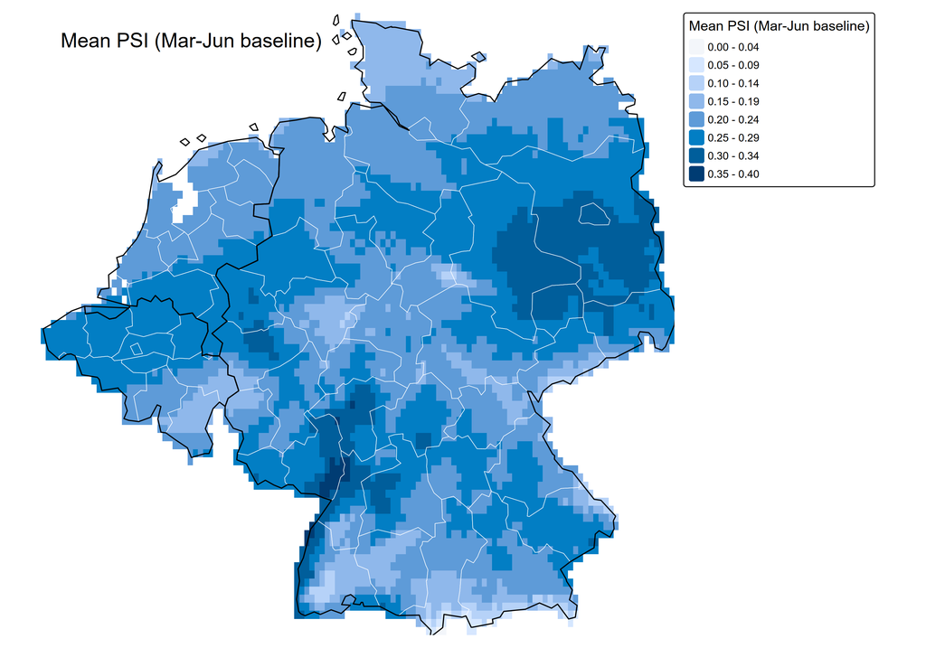

Figure 1a. Mean PSI (Mar-Jun baseline, 2011-2022)

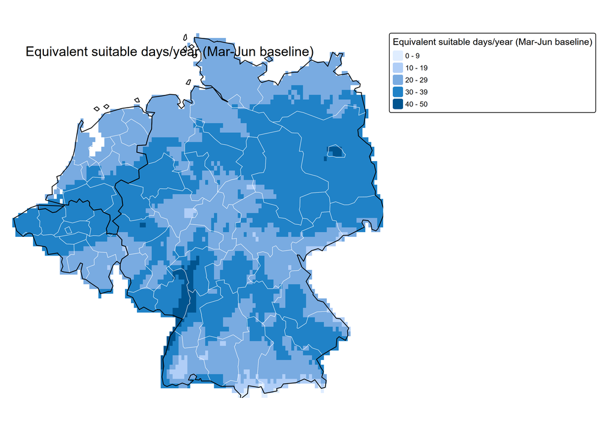

Figure 1b. Equivalent suitable days/year (Mar-Jun baseline)

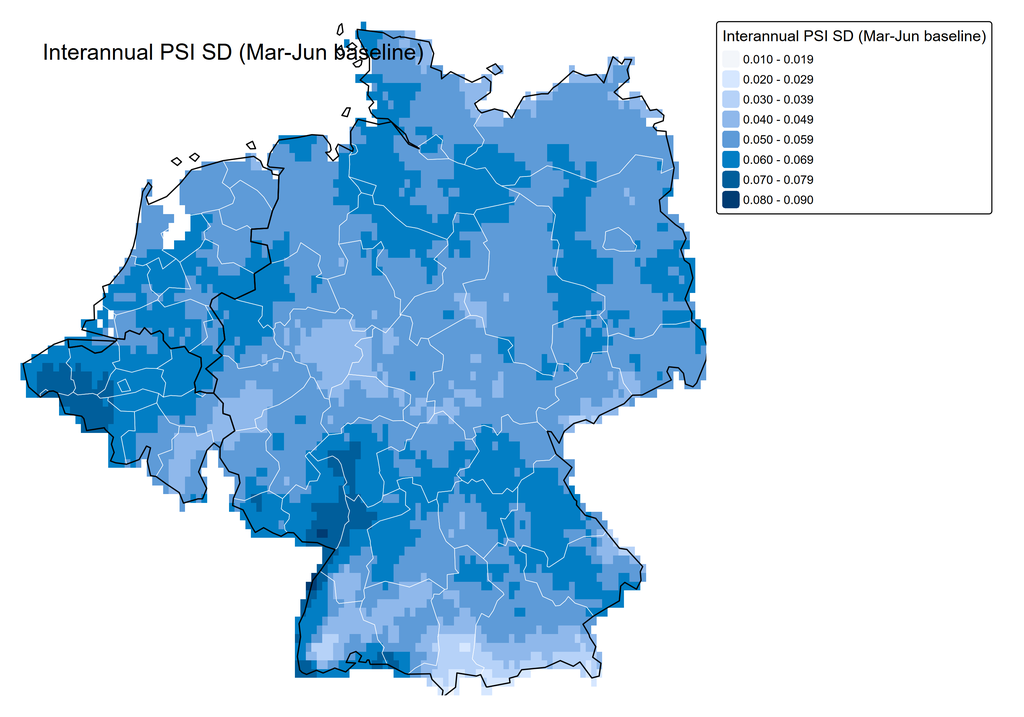

Figure 2. Interannual PSI standard deviation (Mar-Jun baseline, 2011-2022)

### 6.2 Rapeseed: Crop Distribution and Exposure (Q2)

These maps address **Lars US1** (deficit exposure ranking) and **Anneke US3** (suitability overlap identification).

Rapeseed is the most spatially concentrated crop in the SPAM data, with the highest harvested fractions in north-eastern Germany reaching up to 10-12% of cell area. Belgium shows scattered smaller concentrations; the Netherlands has minimal rapeseed presence.

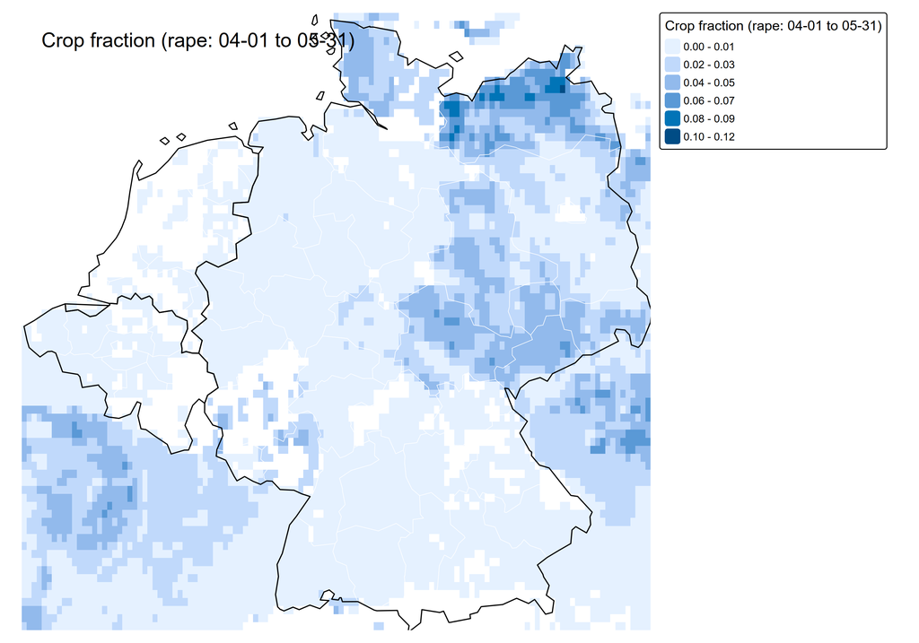

Figure 3a. Rapeseed crop fraction (SPAM 2020)

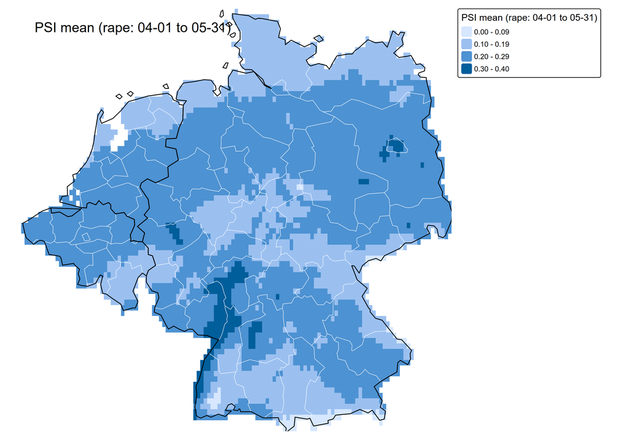

Figure 3b. PSI mean - rapeseed bloom window (Apr-May)

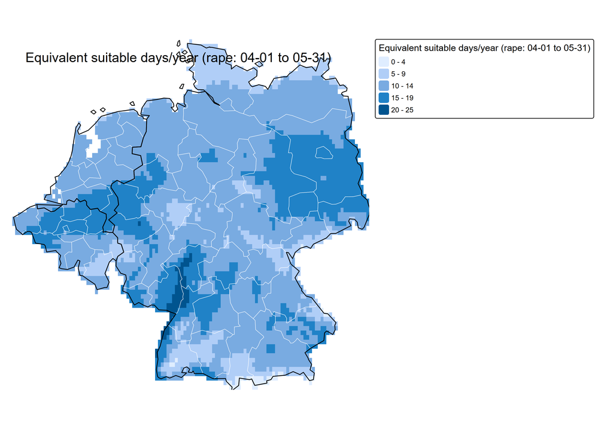

Figure 4a. Equivalent suitable days/year - rapeseed

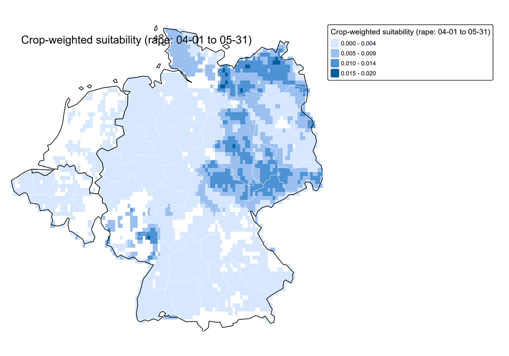

Figure 4b. Crop-weighted suitability - rapeseed

The crop-weighted suitability map confirms that north-eastern Germany holds the best combination of high PSI and high crop intensity; these are Anneke’s primary demonstration-plot candidate regions. The deficit exposure map tells a more sobering story for Lars: despite relatively good average PSI, the north-east also accumulates the highest absolute deficit exposure because it holds the most crop area. Mecklenburg-Vorpommern carries the highest regional deficit burden.

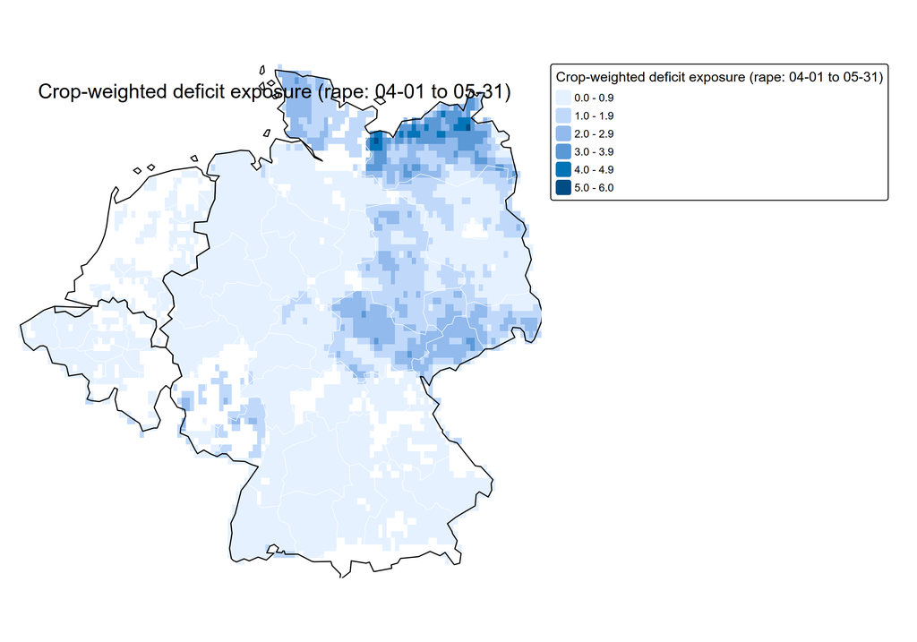

Figure 5a. Crop-weighted deficit exposure - rapeseed (deficit-days/year x crop fraction)

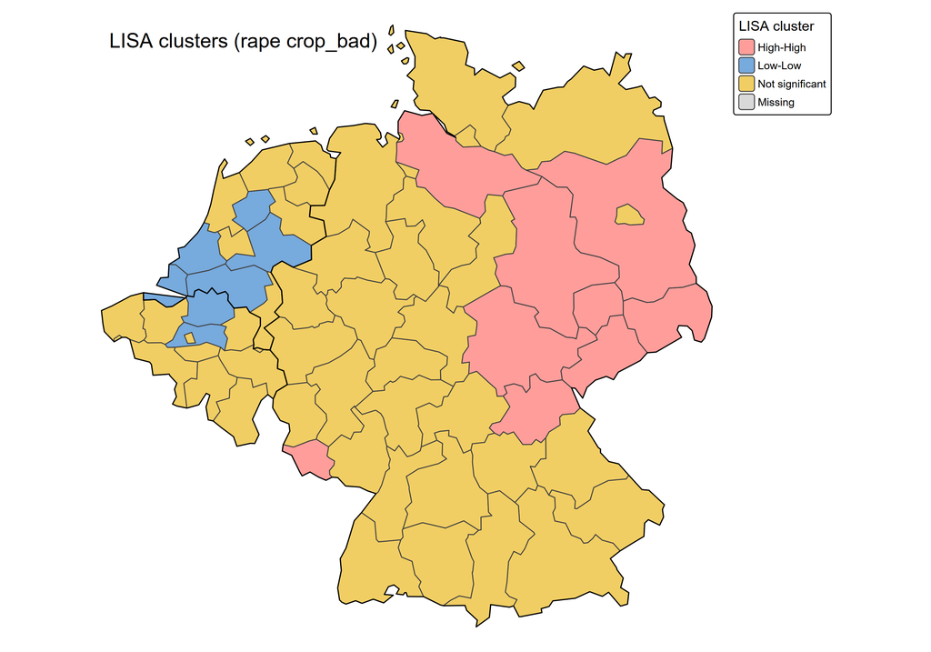

Figure 5b. LISA clusters - rapeseed deficit exposure (p <= 0.05)

LISA confirms a statistically significant High-High cluster in the north-east (Global Moran’s I = 0.577, p < 0.01). The Netherlands shows a Low-Low cluster, reflecting both low rapeseed presence and moderate climate conditions. This asymmetry where the best average suitability and the highest risk co-occur due to crop concentration is a key finding for crop insurance pricing.

### 6.3 Temperate Fruit: Crop Distribution and Exposure (Q2)

The Rhine-Maas corridor is within Anneke’s cooperative territory, making this directly actionable for **Anneke US3 and US4**.

Temperate fruit cultivation is geographically distinct from rapeseed: the highest TEMF fractions appear in the Rhine-Maas corridor straddling the NL/BE border and in southern Germany (Bodensee region, Rhine valley). Eastern Germany is largely absent from TEMF maps.

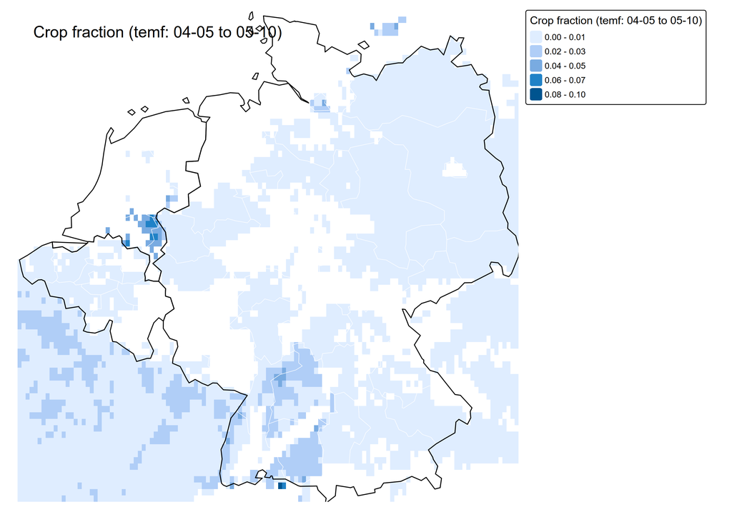

Figure 6a. Temperate fruit crop fraction (SPAM 2020)

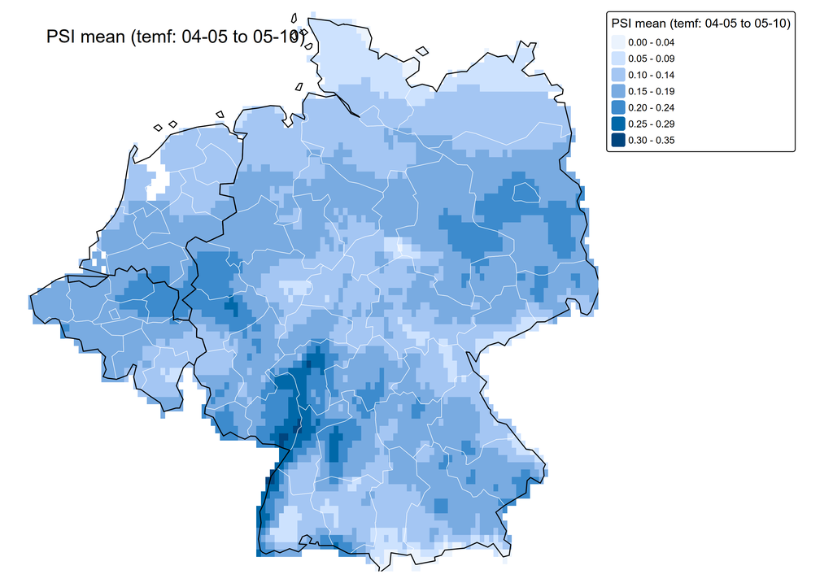

Figure 6b. PSI mean - temperate fruit bloom window (Apr 5 to May 10)

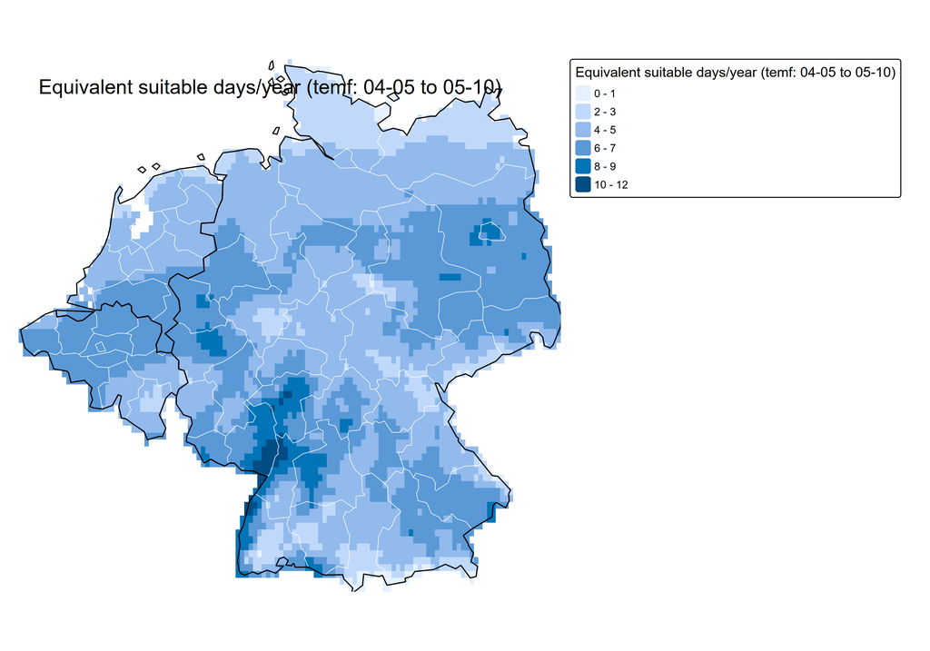

Figure 7a. Equivalent suitable days/year - temperate fruit

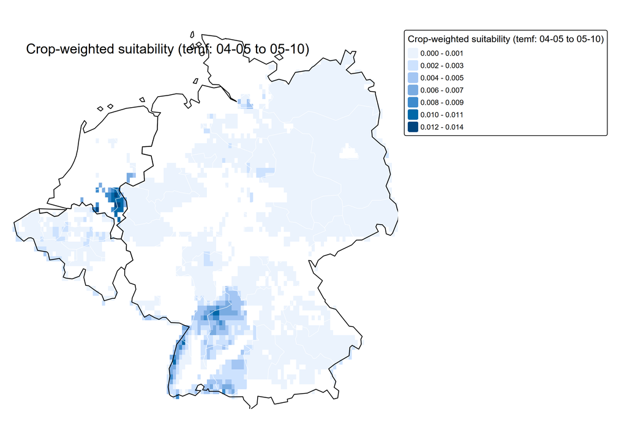

Figure 7b. Crop-weighted suitability - temperate fruit

The deficit exposure map highlights the NL/BE Rhine-Maas cluster and the Bodensee area as the two primary risk zones for TEMF. The LISA map shows a localised High-High cluster at the NL/BE border. Moran’s I is moderate (I = 0.295, p = 0.01), reflecting TEMF’s more fragmented spatial distribution compared to rapeseed.

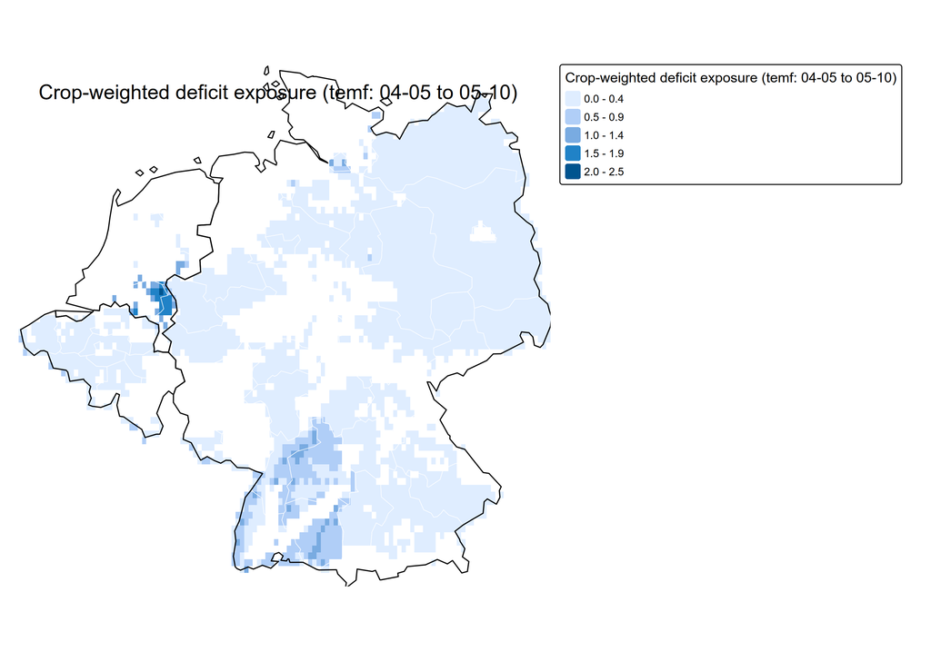

Figure 8a. Crop-weighted deficit exposure - temperate fruit

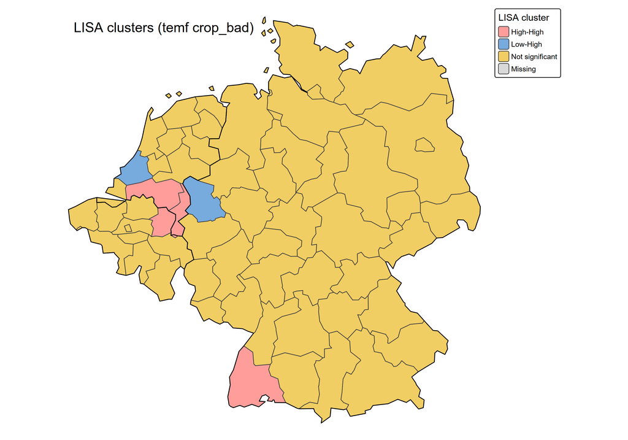

Figure 8b. LISA clusters - temperate fruit deficit exposure (p <= 0.05)

### 6.4 Sunflower: Crop Distribution and Exposure (Q2)

Results confirm **Lars US1**: sunflower carries low systematic climate risk across the study area.

Sunflower has a markedly different profile. SPAM data shows very low fractions across most of the study region; only a few cells in eastern Germany and isolated areas near the Belgian/French border register non-trivial values. The bloom window (10 Jul - 10 Aug) falls in mid-summer when temperatures are systematically higher, yielding high PSI values almost everywhere. Mean PSI ranges from 0.50 to 0.90 across most of the study area, and equivalent suitable days typically exceed 20 per season. As a result, crop-weighted deficit exposure is near-zero for most regions.

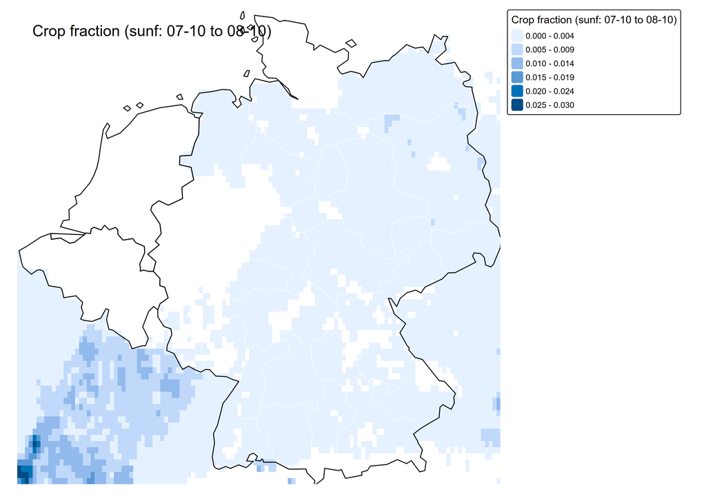

Figure 9a. Sunflower crop fraction (SPAM 2020)

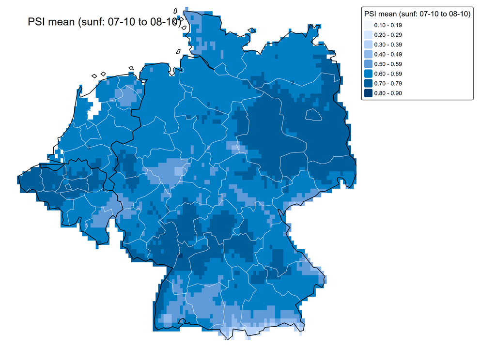

Figure 9b. PSI mean - sunflower bloom window (Jul 10 to Aug 10)

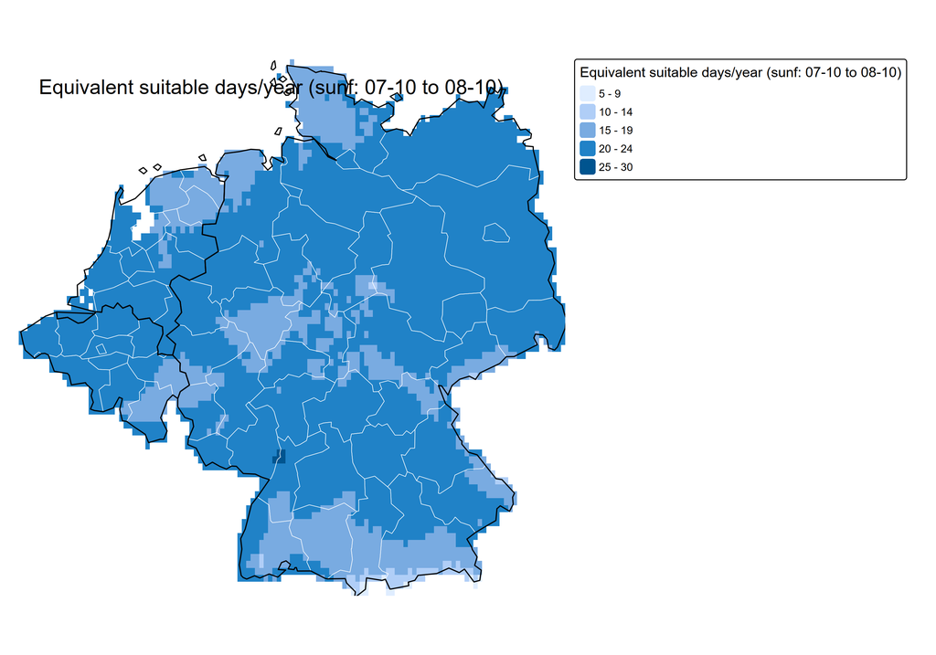

Figure 10a. Equivalent suitable days/year - sunflower

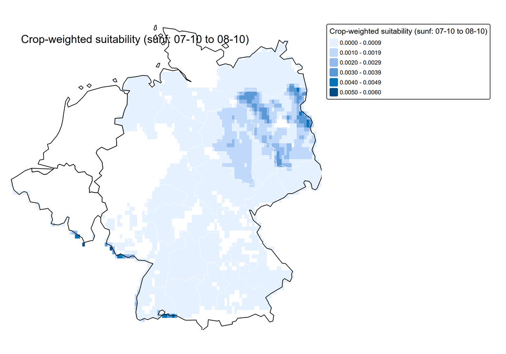

Figure 10b. Crop-weighted suitability - sunflower

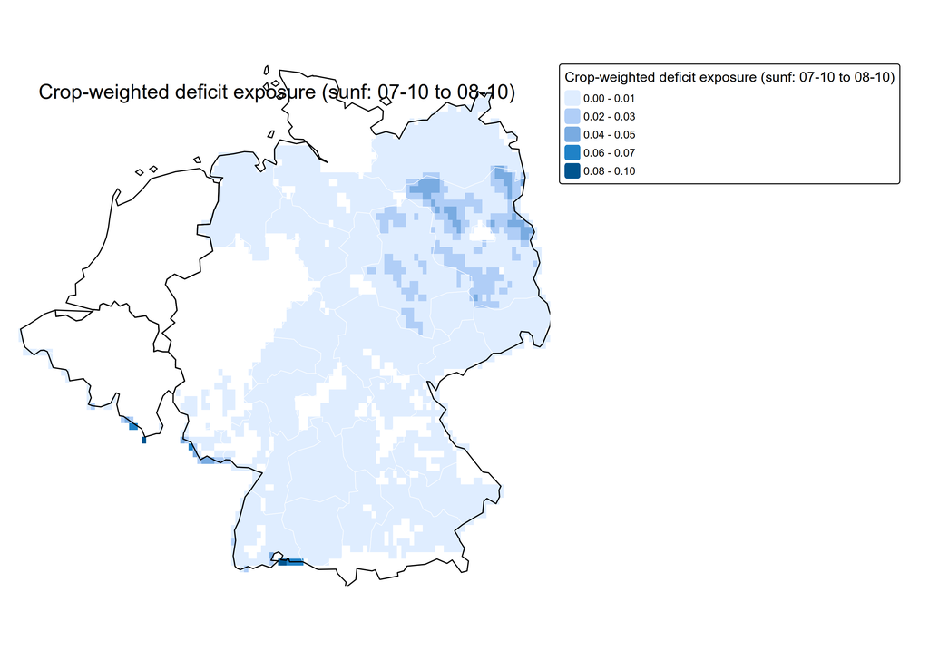

Figure 11a. Crop-weighted deficit exposure - sunflower

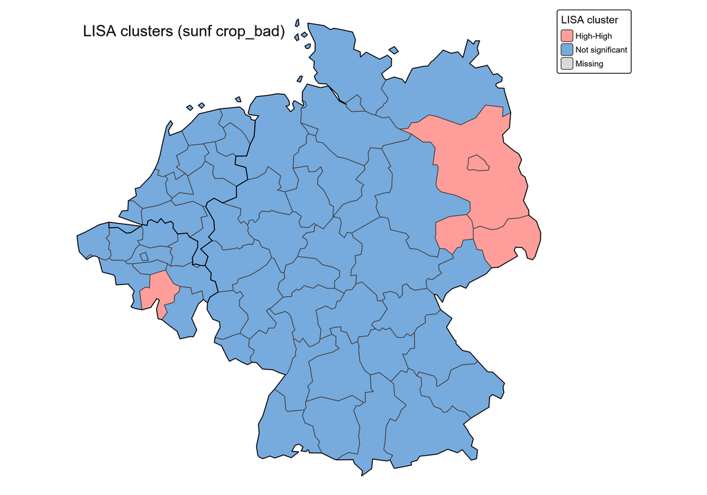

Figure 11b. LISA clusters - sunflower deficit exposure (p <= 0.05)

### 6.5 Time-Series: Daily PSI for Top Exposure Regions (2020)

Addresses **Lars US2**: intra-seasonal variability for the highest-risk regions per crop, illustrating the difference between consistently poor conditions and episodic bad years.

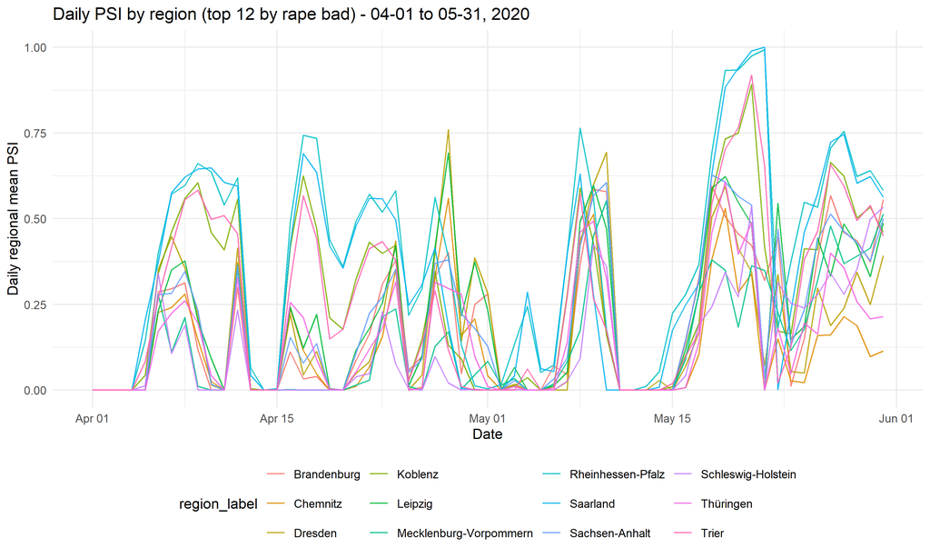

Figure 12a. Daily PSI - top 12 regions by rapeseed deficit exposure, Apr 1 to May 31, 2020

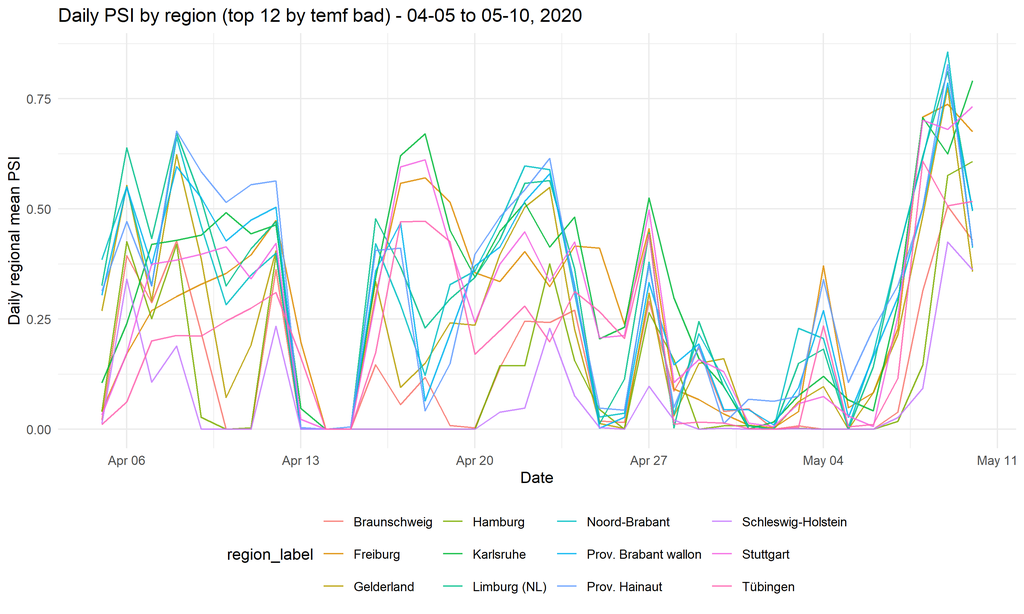

Figure 12b. Daily PSI - top 12 regions by temperate fruit deficit exposure, Apr 5 to May 10, 2020

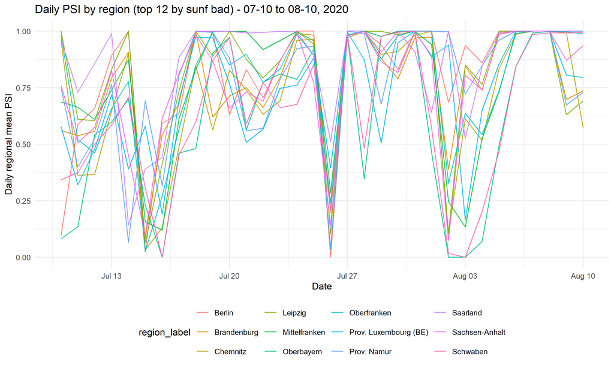

Figure 12c. Daily PSI - top 12 regions by sunflower deficit exposure, Jul 10 to Aug 10, 2020

### 6.6 Spatial Clustering Summary (Q3)

Directly addresses **Anneke US4**: is poor pollination climate clustered or random?

[output not shown]

Across all three crops, crop-weighted suitability and deficit exposure show statistically significant positive spatial autocorrelation (all Moran’s I > 0.29, p <= 0.01). This confirms that climate-driven pollination risk is not randomly distributed but spatially structured. For **Anneke**, regional advisory campaigns are more efficient than farm-by-farm outreach: targeting a High-High cluster reaches multiple high-risk farms simultaneously. For **Lars**, regional portfolio diversification does not fully hedge climate risk because policies held within the same cluster share correlated seasonal exposure. Rapeseed shows the strongest clustering (I = 0.577), making it the crop where spatial targeting delivers the greatest analytical leverage.

## 7. Conclusions

Temperate fruit and sunflower show different geographic profiles, with fruit risk concentrated at the NL/BE border and sunflower carrying low systematic climate risk across the study area. Spatial autocorrelation is strong and significant for all crops, validating a regional clustering approach over individual farm-level analysis. For **Lars Hoffmann**, the LISA maps and ranking tables provide the spatial risk stratification needed to differentiate regional premiums. For **Anneke Visser**, the crop-weighted suitability surfaces identify benchmark zones and priority intervention clusters for advisory deployment.

## 8. References

1. Vicens, N., and Bosch, J. (2000). Weather patterns and visitation rates of honey bees and carpenter bees on almond flowers. *Annals of the Entomological Society of America*, 93(2), 240-246.
2. Blazyte-Cereskiene, L., Vaitkeviciene, G., Venskutonyte, S., and Buda, V. (2010). Honey bee foraging behaviour in oilseed rape crops: The effect of weather conditions. *Zemdirbyste-Agriculture*, 97(3), 93-100.
3. Klein, A. M., Vaissiere, B. E., Cane, J. H., Steffan-Dewenter, I., Cunningham, S. A., Kremen, C., and Tscharntke, T. (2007). Importance of pollinators in changing landscapes for world crops. *Proceedings of the Royal Society B*, 274(1608), 303-313.
4. Lawson, D. A., and Rands, S. A. (2019). The effects of rainfall on plant-pollinator interactions. *Arthropod-Plant Interactions*, 13, 561-570. https://doi.org/10.1007/s11829-019-09686-z
5. Vincze, C., Leelossy, A., Zajacz, E., et al. (2025). A review of short-term weather impacts on honey production. *International Journal of Biometeorology*, 69, 303-317. https://doi.org/10.1007/s00484-024-02824-0
6. Cornes, R. C., van der Schrier, G., van den Besselaar, E. J. M., and Jones, P. D. (2018). An Ensemble Version of the E-OBS Temperature and Precipitation Data Sets. *Journal of Geophysical Research: Atmospheres*, 123, 9391-9409. https://doi.org/10.1029/2017JD028200
7. You, L., Wood-Sichra, U., Fritz, S., Guo, Z., See, L., and Koo, J. (2014). Spatial Production Allocation Model (SPAM) 2005 v2.0. IFPRI. https://doi.org/10.7910/DVN/DHXBJX
8. Eurostat. NUTS: Nomenclature of Territorial Units for Statistics. https://ec.europa.eu/eurostat/web/nuts